# Cours CRC - partie 3

Hoguin

2021

## Calcul d’un CRC polynomial

Mathématiquement, on peut écrire un polynôme tel que
$$P(X)=X^5+X^3+X^2+X+1$$

On pourra alors traduire ce polynôme par le suite de bits :

$$P(X)=X^5+X^3+X^2+X+1 = 1X^5+0X^4+1X^3+1X^2+1X+1 \iff M=101111$$

## Exercices

1. Quel mot binaire est associé au polynôme suivant : $P(x)=X^7+X^6+X^2$ ?
2. Inversement, quel est le polynôme associé au mot binaire suivant $11000011$ ?

## Division des polynômes

On peut diviser deux mots binaires de la manière suivante :

voir la vidéo : division

Remarques :

- Si le Mot est de longueur $n+1$ alors le polynome est de degré $n$
- Si le polynôme est de degré $n$ alors le mot est de longueur $n+1$
- Si le diviseur est de longueur $k$ alors le reste est de longueur $k-1$

## Exercice

Soit le mot $M=1010100001$ à diviser par $G=1010$. Déterminer le reste de la division de $M$ par $G$

## Algorithme du calcul de CRC

1. Soit $M$ le mot dont on veut calculer le CRC et on suppose que le le mot est de longueur $n$
2. SOit $G$ le polynôme générateur du CRC, on suppose que le polynôme $G$ est de degré $k$, avec $k < n$
3. On ajoute au mot $M$, $k$ bits égaux à $0$. Cela forme alors un mot $M'$ de longueur $n+k$ bits
4. On effectue alors la division de $M'$ par $G$
5. Le reste de la division précédente est le CRC du mot $M$

## Exemple de calcul du CRC

1. SOit $M=1100100100$ donc de longueur $10$ bits
2. Soit $G$ le polynôme générateur $G(X)=X^4+X+1$. qui correspond à $G=10011$ donc de longueur $5$
3. On ajoute à $M$ les $4$ bits égaux à $0$, soit $M'=11001001000000$
4. On effectue la division de $M'$ par $G$, et on obtient le résultat suivant :

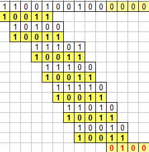

division01

5. Le reste est de longueur $4$ (ce qui correspond au degré du polynôme $G$) et vaut **0100**
6. Le CRC de $M$ est **0100**

## Exercice

Calculer le CRC du polynôme $P(x)=x^8+1$ avec le polynôme générateur suivant $G(x)=x^4+x^2+1$